# Chapter 4 - Soundscape Translation Data: Analysis, Validation, and Application

Authors

Affiliations

Andrew Mitchell

University College London

Tin Oberman

University College London

Francesco Aletta

University College London

Jian Kang

University College London

Östen Axelsson

Karolinska Institutet

Abstract

Keywords

Soundscape

# 1 Introduction

```python
# Setup Python

from enum import Enum, ReprEnum
from num2words import num2words
import pandas as pd
from tqdm.auto import tqdm
from IPython.display import Markdown
import warnings
from typing import Literal

import soundscapy as sspy
import circumplex
import rthor

from computation import scm_inst

SATP_VERSION = "v1.5"

SCM = circumplex.get_instrument("SCM")

scales = SCM.scale_abbrevs
equal_angles = SCM.get_angles()
```

```python
# Define fit metrics


class RTHORfit(float, ReprEnum):
    CI = 0.7
    p = 0.05


class CircEfit(float, ReprEnum):
    CFI = 0.92
    GFI = 0.9
    SRMR = 0.08


class SSMfit(float, ReprEnum):
    R2 = 0.8
    A = 0.15


class CongruenceFit(float, ReprEnum):
    COSINE = 0.9
    PROCRUSTES = 0.9
```

```python
satp = sspy.databases.satp.load_zenodo(version=SATP_VERSION)

languages = sorted(satp["Language"].unique())
institutions = satp["Institution"].unique()

print(f"Total rows: {len(satp):,}")
print(f"Languages ({len(languages)}): {languages}")
print(f"Institutions ({len(institutions)}): {institutions}")
```

```
Total rows: 22,355
Languages (23): ['alb', 'arb', 'bra', 'cmn', 'deu', 'ell', 'eng', 'fra', 'hrv', 'ind', 'ita', 'jpn', 'kor', 'nld', 'pol', 'por', 'spa', 'swe', 'tha', 'tur', 'vie', 'yue', 'zsm']
Institutions (24): <StringArray>
['UBT', 'BIS', 'USP', 'SJZ', 'TUB', 'TUC', 'UCL', 'UGE', 'FER', 'ITB', 'POT',
 'FUU', 'HAN', 'RUG', 'AMU', 'LNC', 'UGR', 'UCH', 'STU', 'NTU', 'CKU', 'SHU',
 'ANR', 'UPM']
Length: 24, dtype: str
```

In the following chapters of this volume, case studies of individual languages are presented, demonstrating an array of approaches to evaluating the validity of proposed translations of the Soundscape Circumplex Model (SCM) questionnaire. This diversity of translation and evaluation methodologies allows for a nuanced understanding of the particular challenges inherent to each language and translation attempt. However, to ensure consistency and comparability across all twenty-three languages included in the Soundscape Attributes Translation Project (SATP), it was necessary to develop a standardised quantitative procedure which can evaluate all languages on the same basis and consider the compiled dataset as a whole.

This chapter therefore presents such a procedure: a systematic, four-step approach for evaluating and adjusting the quasi-circumplex structure of translated versions of the SCM questionnaire. The outcome of this procedure is a classification of each translation’s structural validity and a set of adjusted angles that can be applied to correct for structural deviations when computing soundscape coordinates. The procedure consists of four key steps:

1. testing for the presence of a circular ordering in the translated instrument’s scales,
2. assessing the fit of Browne’s (1992) circumplex structural equation models to the data and deriving adjusted angles,
3. using the Structural Summary Method to locate circumplex scales within each language’s empirical circumplex space, and
4. testing the congruence between these empirical locations and theoretical expectations.

Each step serves as a sequential gate: languages which fail a given step are excluded from subsequent analysis and classified accordingly within a three-tier confidence system.

As described in Chapter 1, the SATP initiative brought together research groups from around the world to produce and evaluate translations of the eight perceptual attribute questions (PAQs) used in the SCM. The listening experiment protocol used to collect data for each translation is detailed in Chapter 3. This chapter focuses exclusively on the quantitative validation procedure applied to the compiled SATP v1.5 dataset, which encompasses twenty-three languages collected across 24 institutions.

We begin with a brief overview of the circumplex model and its relevance to the challenge of translating psychometric instruments (Section 2). We then present the four-step procedure in detail (Section 3), including the dataset preparation and the statistical methods employed at each stage. The results of applying this procedure to the SATP v1.5 dataset are presented in Section 4, followed by a demonstration of how the derived adjusted angles can be practically applied to compute corrected soundscape coordinates (Section 5). The chapter concludes with a discussion of the findings and their implications for cross-cultural soundscape research (Section 6).

# 2 The Soundscape Circumplex Model and Translation Challenge

## 2.1 Defining the circumplex model

The concept of the psychometric circumplex model, first introduced by Guttman (1954), revolves around the idea of a circular relationship among variables. This circular relationship can be seen by identifying certain correlation patterns within the correlation matrix among variables, when appropriately ordered (Browne 1992). In the case of the circular structure, the strength of the correlation coefficients in the matrix decreases as you move away from the diagonal, and then increases again as you move towards the opposite diagonal. This pattern of correlations can be seen in Table 1.

Table 1: Theoretical pattern of the correlation matrix corresponding to a circular structure. $\rho_1 > \rho_2 > \rho_3 > \rho_4$ (Gurtman and Pincus 2000).

|  | V1 | V2 | V3 | V4 | V5 | V6 | V7 | V8 |
| --- | --- | --- | --- | --- | --- | --- | --- | --- |
| V1 | 1 |  |  |  |  |  |  |  |
| V2 | $\rho_1$ | 1 |  |  |  |  |  |  |
| V3 | $\rho_2$ | $\rho_1$ | 1 |  |  |  |  |  |
| V4 | $\rho_3$ | $\rho_2$ | $\rho_1$ | 1 |  |  |  |  |
| V5 | $\rho_4$ | $\rho_3$ | $\rho_2$ | $\rho_1$ | 1 |  |  |  |
| V6 | $\rho_3$ | $\rho_4$ | $\rho_3$ | $\rho_2$ | $\rho_1$ | 1 |  |  |
| V7 | $\rho_2$ | $\rho_3$ | $\rho_4$ | $\rho_3$ | $\rho_2$ | $\rho_1$ | 1 |  |
| V8 | $\rho_1$ | $\rho_2$ | $\rho_3$ | $\rho_4$ | $\rho_3$ | $\rho_2$ | $\rho_1$ | 1 |

This pattern of the correlation matrix indicates that the variables are ordered in a circular fashion, with the strongest correlations between adjacent variables, and the weakest correlations between variables that are furthest apart. It also means that the correlations between these variables follow a pattern that increases and decreases in a way that resembles a cosine wave, as explained by Yik and Russell (2004) and Grassi, Luccio, and Blas (2010). This circular arrangement of the variables can be tested using a method proposed by Rounds et al. (2000).

Browne (1992) further expanded on the circumplex model by differentiating between equal spacing and equal communality (or radii) constraints. Browne described four variations of circumplex models, which include three types of quasi-circumplex models and one circulant model. These variations include the unconstrained or loosely ordered quasi-circumplex, the equal spacing quasi-circumplex, the equal communality quasi-circumplex, and the circulant model that maintains both equal spacing and equal communality.

In certain instances, the rigidity of a circumplex may be relaxed, leading to the concept of a quasi-circumplex. The term “quasi” implies a departure from strict adherence to even spacing and equal communality, allowing for some flexibility in the arrangement of variables. This flexibility is often necessary in order to accommodate the complexity of psychological constructs, which may not always fit neatly into a rigid circular structure. The quasi-circumplex refers to any graphical or conceptual representation where variables or dimensions are organised in a circular or circular-like manner. This umbrella term recognises the spectrum of circular models, acknowledging variations in the spacing, organisation, and relationships among variables.

As researchers encounter the intricacies of psychological spaces, the choice between a strict circumplex, a quasi-circumplex, or a more general circular structure becomes crucial. These models play a pivotal role in visualising and understanding the complex interplay of variables, offering researchers nuanced frameworks to explore and interpret their data.

Rogoza, Cieciuch, and Strus (2021) (Figure 1) provides a helpful visualisation of these circumplex variations:

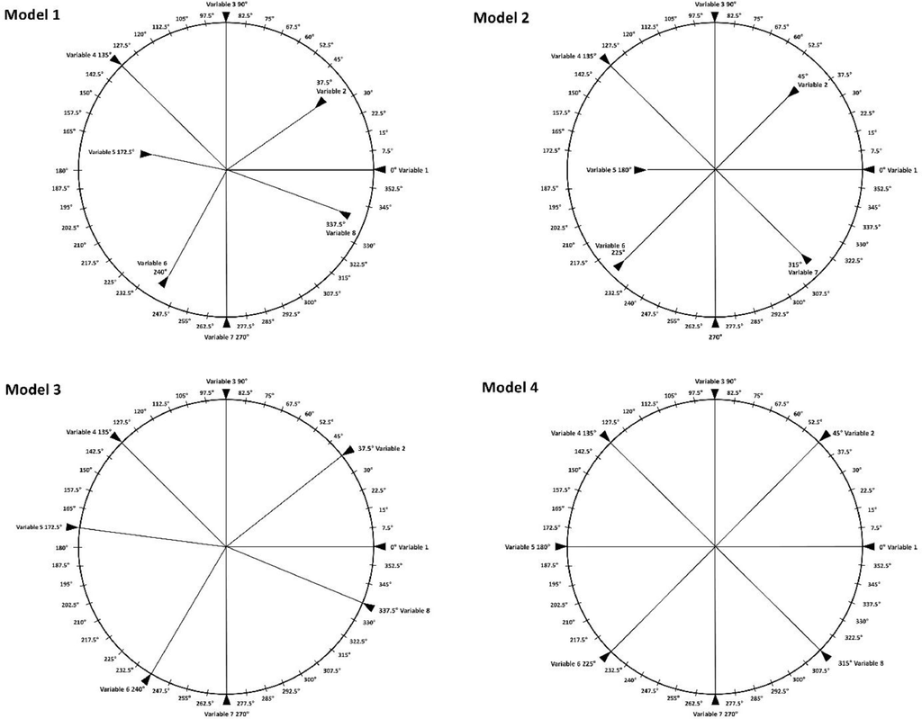

Figure 1: Graphical representation of four variations of circumplex model structure. Model 1 is a circular model, Model 2 is a quasi-circumplex model with equal spacing, Model 3 is a quasi-circumplex model with equal communality, and Model 4 is a circumplex model with equal spacing and equal communality.[^1]

## 2.2 Translating circumplex instruments

Typically, circumplex scales are measured via a series of questions in a survey instrument. These instruments are initially developed in one language and the validity and structure of the instrument is tested in that language. Often these instruments are directly translated into other languages to enable their use in other countries. However, the validity of the instrument in the new language is not guaranteed. Changes in the correlation structure can be caused by errors in the translation process, by semantic and linguistic differences between the translated scales even given a valid translation, and by a lack of generalisability of the circumplex instrument.

It is easy to see how errors in the translation process can lead to changes in the correlation structure. For example, if a question is mistranslated, then the responses to that question will not be correlated with the responses to the other questions in the instrument. Semantic and linguistic differences between the translated scales can also lead to changes in the correlation structure. For example, if a question is translated into a language where the concept does not exist or cannot be easily expressed, then the responses to that question will not be correlated with the responses to the other questions in the instrument. Finally, it may be that even if the original instrument is valid for, e.g., the English-speaking population, it may not be valid for other populations due to cultural differences.

### 2.2.1 Goals of translating a circumplex instrument

Two approaches could be taken when attempting to translate a circumplex survey instrument. The first approach would attempt to achieve direct concurrence with the original instrument, where each scale is directly correlated with the corresponding scale from the original instrument. If the underlying circumplex structure is identical between the two languages, then this approach would allow for the most direct comparison between the two languages. However, if the circumplex structure is not identical between the two languages, then this approach would lead to a loss of information. The second approach would attempt to achieve the same circumplex structure in the new language as in the original language, allowing for the most direct comparison between the two translations.

In this second approach, identifying the differences in structure between translations enables the process of locating an external variable to be corrected for the differences in structure. Given that at minimum a quasi-circumplex structure can be confirmed, then the deviations in either the angles or communalities from the ideal circumplex structure can be measured and accounted for. When this is done separately for the original and translated instruments, then an external variable which has the same theoretical location in both instruments should be located in the same location in both corrected instruments.

This has an important impact on comparing results under the two translations. If an external variable is theoretically located in a single, fixed position in the circumplex space, locating it without accounting for the differences in structure between the two translations will lead to different locations in the two translations. The interpretation of this result would then be that the external variable is located in different positions in the two languages. However, if the differences in structure are accounted for, then the external variable should be located in the same position in both translations. By applying the correction we can attempt to discover differences in the effect of external variables, independent of the differences in structure between the two translations. It is this second approach — structural equivalence with angle corrections — that forms the basis of the procedure presented in this chapter.

# 3 A Four-Step Validation Procedure

In Rogoza, Cieciuch, and Strus (2021), the authors propose a three-step procedure for assessing circumplex models. Their steps are:

1. verify whether the analysed model conforms to a circumplex structure using Structural Equation Modelling based on Browne (1992)’s model;
2. test the possibility of locating an external variable within the empirical circumplex using the Structural Summary Method (Gurtman 1994); and
3. assess the extent to which empirical locations are congruent with theoretical predictions within the circumplex structure.

We expand upon this three-step procedure and adapt it to the specific case of testing multiple translations of the same circumplex instrument. Our goals are, for each translation, to verify the quasi-circumplex structure, to derive angle corrections that account for structural deviations, and to test whether the corrected circumplex can reliably locate external variables in positions congruent with those of the overall dataset. We achieve this by adding an initial step that incorporates Rounds et al. (2000)’s test of circular ordering, confirming that the rank order of the scales is preserved across translations before proceeding to more detailed structural analysis. The resulting four-step procedure is summarised as follows:

1. **Step 1 — Circular Order**: Confirm that the circular ordering of the eight PAQ scales is maintained in each translation, using Tracey’s randomisation test of the circular order model.
2. **Step 2 — Structural Equation Modelling**: Fit Browne’s circular stochastic process model to assess the quasi-circumplex structure and extract adjusted angular positions for each scale.
3. **Step 3 — Structural Summary Method**: Locate the overall dataset’s circumplex scales within each language’s circumplex space using SSM analysis with the adjusted angles, verifying that sinusoidal profiles achieve adequate fit.
4. **Step 4 — Congruence Testing**: Test the congruence between the empirically located positions and their theoretical expectations using cosine similarity and Procrustes distance.

Languages are then assigned to one of three confidence tiers (Low, Medium, or High) based on their performance across these steps, providing a transparent summary of each translation’s structural validity.

## 3.1 Dataset and Data Preparation

```python
class LanguageNames(str, Enum):
    alb = "Albanian"
    arb = "Arabic"
    bra = "Brazilian Portuguese"
    cmn = "Mandarin Chinese"
    deu = "German"
    ell = "Greek"
    eng = "English"
    fra = "French"
    hrv = "Croatian"
    ind = "Indonesian"
    ita = "Italian"
    jpn = "Japanese"
    kor = "Korean"
    nld = "Dutch"
    pol = "Polish"
    por = "Portuguese"
    spa = "Spanish"
    swe = "Swedish"
    tha = "Thai"
    tur = "Turkish"
    vie = "Vietnamese"
    yue = "Cantonese"
    zsm = "Malay"

    def print_name_lbl(self):
        return f"{self.value} ({self.name})"

    @classmethod
    def print_all_names(cls, incl_langs: list[str] | None = None):
        langs_to_include = (
            [cls[lang] for lang in incl_langs] if incl_langs else [lang for lang in cls]
        )
        formatted_names = [lang.print_name_lbl() for lang in langs_to_include]
        all_but_last_item = ", ".join(formatted_names[:-1])
        return f"{all_but_last_item}, and {formatted_names[-1]}"
```

The analysis presented in this chapter draws on the Soundscape Attributes Translation Project (SATP) dataset, version v1.5. This dataset compiles responses from listening experiments conducted across 23 languages: Albanian (alb), Arabic (arb), Brazilian Portuguese (bra), Mandarin Chinese (cmn), German (deu), Greek (ell), English (eng), French (fra), Croatian (hrv), Indonesian (ind), Italian (ita), Japanese (jpn), Korean (kor), Dutch (nld), Polish (pol), Portuguese (por), Spanish (spa), Swedish (swe), Thai (tha), Turkish (tur), Vietnamese (vie), Cantonese (yue), and Malay (zsm). Responses from the LNC institution were excluded from the analysis due to differences in data collection protocol. The details of the experimental protocol, stimuli, and participant recruitment for each language are described in the respective language chapters of this volume and are not repeated here.

Each participant rated 27 soundscape recordings on the eight Perceptual Attribute Questionnaire (PAQ) scales: *pleasant* (PAQ1), *vibrant* (PAQ2), *eventful* (PAQ3), *chaotic* (PAQ4), *annoying* (PAQ5), *monotonous* (PAQ6), *uneventful* (PAQ7), and *calm* (PAQ8).

```python
SCM.info(items=False, norms=False)
```

```
SCM: Soundscape Circumplex Model
0 items, 8 scales, 0 normative data sets
Axelsson, Nilsson, & Berglund (2010)
< https://doi.org/10.1121/1.3493436 >


The SCM contains 8 scales:
├── PAQ1 (0°): Pleasant
├── PAQ2 (45°): Vibrant
├── PAQ3 (90°): Eventful
├── PAQ4 (135°): Chaotic
├── PAQ5 (180°): Annoying
├── PAQ6 (225°): Monotonous
├── PAQ7 (270°): Uneventful
└── PAQ8 (315°): Calm


The SCM is rated using the following 5-point scale:
  0. Strongly disagree
  1. Somewhat disagree
  2. Neither agree nor disagree
  3. Somewhat agree
  4. Strongly agree
```

The sample sizes reported in the results tables represent the total number of observations (i.e. participant $\times$ recording combinations) rather than the number of unique participants; for example, a language with 68 participants yields approximately $68 \times 27 = 1{,}836$ observations.

```python
# Missing values
# We can see that only a handful of rows have missing values in the PAQ columns.
satp[satp[scales].isnull()].any(axis=1)

# For this analysis, we will simply drop these rows, leaving us with a clean dataset
# of PAQ responses for the following steps.
# We're not concerned with missing Age, Gender, or loud values.
satp = satp.dropna(subset=scales)
satp.isnull().sum()
```

```
Language           0
Institution        0
Recording          0
Participant        0
Age             5206
Gender          6825
PAQ1               0
PAQ2               0
PAQ3               0
PAQ4               0
PAQ5               0
PAQ6               0
PAQ7               0
PAQ8               0
loud           15015
sequence_id    15582
dtype: int64
```

Prior to analysis, the PAQ responses were ipsatised using grand-mean centring. For each participant, a single grand mean was computed across all eight PAQ scales and all 27 recordings, and this value was subtracted from every individual response. This procedure removes systematic individual differences in overall rating tendency — for instance, participants who consistently use the upper or lower end of the response scale — without removing variation between scales or between recordings. Grand-mean centring is recommended by Girard, Zimmermann, and Wright (2024) for circumplex analyses and is implemented in `soundscapy` as the default ipsatization method.

## 3.2 Step 1 — Circular Order

The first step verifies that the process of translation has not altered the rank ordering of correlations among the eight PAQ scales. Following the approach taken in Gurtman and Pincus (2000) and previously employed for the SCM by Lam et al. (2022), we apply the randomisation test of the circular order model developed by Rounds et al. (2000). This test compares the observed order relations in a correlation matrix against the order relations predicted by a hypothesised circular arrangement of the scales.

The key index for this test is Hubert and Arabie (1987)’s Correspondence Index (CI), a descriptive measure reflecting the degree to which the model’s ordered predictions align with the observed correlation matrix. The CI is calculated as the proportion of predictions met minus the proportion violated, yielding a range from $+1.0$ (all predictions fulfilled) to $-1.0$ (all predictions contradicted). A randomisation test (Tracey 1997) is applied to the hypothesised order relations, producing an exact probability that represents the likelihood of achieving the observed CI value under all possible permutations of the correlation matrix.

We apply the following thresholds: a CI value greater than 0.7 and a randomisation $p$-value less than 0.05. Languages failing to meet these thresholds are excluded from subsequent steps, as failure indicates that the fundamental circular ordering of the PAQ scales has not been preserved in translation. This may reflect translation errors, semantic shifts that disrupt the expected pattern of inter-scale correlations, or genuine cultural differences in how the soundscape attributes relate to one another.

```python
# rthor.test() can take a list of dataframes
# So we use list comprehension to split our `satp` dataframe into separate
# dataframes for each language, i.e. [eng_df, spa_df, ...]
rthor_results = rthor.test(
    [satp.query("Language == @lang")[SCM.scale_abbrevs] for lang in languages],
    labels=languages,
    order="circular8",
)

rthor_results["passes"] = (rthor_results["ci"] > RTHORfit.CI) & (
    rthor_results["p_value"] < RTHORfit.p
)

rthor_passing = rthor_results.query("passes").sort_values("ci")
rthor_failing = rthor_results.query("not passes").sort_values("ci")

pass_step1 = rthor_passing["label"].tolist()
fail_step1 = rthor_failing["label"].tolist()
```

## 3.3 Step 2 — Structural Equation Modelling

For languages that pass the circular order test, we proceed to a more detailed assessment of the circumplex structure using Browne (1992)’s circular stochastic process model with a Fourier series correlation function. This is a non-standard Structural Equation Model (SEM) specifically designed for testing circumplex structures, allowing a researcher to examine the extent to which a sample correlation matrix conforms to a circumplex pattern.

Browne’s model can be fitted under four structural constraints, corresponding to the four circumplex variations described in Section 2.1:

1. **Unconstrained circular**: Free angles and free communalities — the loosest model, testing only whether a circular pattern is present.
2. **Equal-spacing quasi-circumplex**: Angles fixed at 45° intervals, communalities free to vary.
3. **Equal-communality quasi-circumplex**: Angles free to vary, communalities constrained to be equal across scales.
4. **Strict circumplex**: Both angles and communalities constrained — 45° spacing with equal communalities.

```python
# Running CircE for all languages that passed Step 1

satp_s2 = satp.query("Language in @pass_step1").copy()
s2_languages = sorted(satp_s2["Language"].unique())

circe_results: list[sspy.satp.CircEResults] = []
fit_errors: dict[str, Exception] = {}

with warnings.catch_warnings():
    warnings.simplefilter("ignore", UserWarning)
    for lang in tqdm(s2_languages):
        try:
            circe_results.append(
                sspy.satp.fit_circe(
                    satp_s2.query("Language == @lang").rename(
                        columns={"Participant": "participant"}
                    ),
                    language=lang,
                    datasource="SATP",
                    errors="warn",
                )
            )
        except Exception as e:
            fit_errors[lang] = e
```

For the purposes of this validation procedure, the equal-communality quasi-circumplex model (Model 3) is of primary interest. This model allows the angular positions of the scales to deviate from the ideal 45° spacing while constraining all scales to have equal communality (i.e. equal radii in the circumplex space). When this model achieves adequate fit, the estimated angles provide a direct measure of how much each scale’s position deviates from the theoretical circumplex. These *adjusted angles* are extracted and carried forward for use in subsequent steps.

The model is implemented using the CircE package (Grassi, Luccio, and Blas 2010) for R, executed through `soundscapy`’s R interface[^2]. Each of the four model variations is fitted separately for each language, and the results are compiled into a summary table. Model fit is evaluated using three indices, summarised in Table 2:

- **Comparative Fit Index (CFI)** $\geq$ 0.92 (Moshona, Lepa, and Fiebig 2023)
- **Goodness of Fit Index (GFI)** $\geq$ 0.9 (Rogoza, Cieciuch, and Strus 2021)
- **Standardised Root Mean Square Residual (SRMR)** $<$ 0.08 (Hu and Bentler 1999; Moshona, Lepa, and Fiebig 2023; Tarlao, Steffens, and Guastavino 2020)

Table 2: Fit indices and thresholds, including the reference from which the threshold is derived.

| **Fit Index** | **Threshold** | **Reference** |
| --- | --- | --- |
| Correspondence Index (CI) | p < 0.05, CI > 0.70 | Gurtman and Pincus (2000) |
| Comparative Fit Index (CFI) | *0.92* | Moshona, Lepa, and Fiebig (2023) |
| Goodness of Fit Index (GFI) | *0.90* | Rogoza, Cieciuch, and Strus (2021) |
| Standardized Root Mean Square Residual (SRMR) | *0.08* | Hu and Bentler (1999) Moshona, Lepa, and Fiebig (2023) Tarlao, Steffens, and Guastavino (2020) |

A language passes Step 2 if the equal-communality model meets all three thresholds simultaneously, yielding a pass score of 3 out of 3.

```python
# Construct Step 2 SEM Results table
sem_res = pd.concat([r.table for r in circe_results], ignore_index=True)

sem_res["CFI Pass"] = sem_res["cfi"] >= CircEfit.CFI.value
sem_res["GFI Pass"] = sem_res["gfi"] >= CircEfit.GFI.value
sem_res["SRMR Pass"] = sem_res["srmr"] < CircEfit.SRMR.value
sem_res["Score"] = (
    sem_res[["CFI Pass", "GFI Pass", "SRMR Pass"]].sum(axis=1).astype(int)
)
sem_res["Pass"] = sem_res["Score"] >= 3

circe_passing = sem_res.query("model == 'equal_com' & Pass")
circe_failing = sem_res.query("model == 'equal_com' & not Pass")

pass_step2 = circe_passing["language"].tolist()
fail_step2 = circe_failing["language"].tolist()
```

Notably, the Root Mean Square Error of Approximation (RMSEA) is excluded from the analysis. This decision follows both the critique in Rogoza, Cieciuch, and Strus (2021) — who note that RMSEA “becomes biased in the case of high correlations between proximal variables, as found in circumplex models, and should be interpreted with caution” — and the more recent methodological warnings of West et al. (2023) regarding the sensitivity of RMSEA to model characteristics that are inherent to circumplex structures.

Once the equal-communality model is accepted, the adjusted angles it yields describe the empirical angular positions of the eight PAQ scales for that language. If the strict circumplex model were adequate for all languages, these angles would equal the ideal positions (0°, 45°, 90°, …, 315°) and no correction would be needed. In practice, the quasi-circumplex structure of most translations requires that these deviations be measured and accounted for — a process carried out in the subsequent steps.

```python
# Construct Angles dataframe
ang_df = sem_res.query("model == 'equal_com' & language in @pass_step2")[
    ["language"] + SCM.scale_abbrevs
].set_index("language")
```

## 3.4 Step 3 — SSM Analysis

Once the general circumplex structure has been confirmed, we proceed to test whether external variables can be reliably located within each language’s circumplex space. The Structural Summary Method (SSM) provides a technique for summarising correlation patterns among measurements that are hypothesised to conform to a circumplex structure (Gurtman 1994; Rogoza, Cieciuch, and Strus 2021). SSM fits a sinusoidal curve to a set of correlations ($q_i$) as a function of the angular positions ($\theta_i$) of the circumplex scales, optimising three parameters: elevation ($e$), amplitude ($\alpha$), and angular displacement ($d$). The model is expressed as:

$$q_i = e + \alpha \cos(\theta_i - d)
\tag{1}$$

where:

- **Elevation** ($e$) represents the average correlation between the external variable and all circumplex scales, indicating the presence of a general factor.
- **Amplitude** ($\alpha$) measures the distinctiveness of the profile — the distance from the mean correlation to the peak — indicating whether the variable is associated predominantly with a specific region of the circumplex or equally with all regions.
- **Angular displacement** ($d$) denotes the angle at which the profile reaches its maximum, representing the empirical location of the external variable within the circumplex.
- **Model fit** ($R^2$) assesses how well the observed correlation profile conforms to the expected cosine function.

Taking inspiration from Yik and Russell (2004), who propose that one circumplex can be located within another, we use the circumplex structure of the overall SATP dataset as the reference against which each language is tested. Specifically, for each PAQ scale of the reference circumplex (computed as the mean across all languages that passed Steps 1 and 2), we calculate its SSM profile within each language’s circumplex, using that language’s adjusted angles from Step 2. This yields an estimated position ($x_{\text{est}}, y_{\text{est}}$) for each reference scale within the language’s circumplex space.

The process proceeds as follows:

1. For both the reference set (overall dataset) and the test set (individual language), compute the mean value of each PAQ scale for each of the 27 recordings.
2. For each reference scale, calculate the SSM profile by correlating it with the test language’s scale means across recordings, using the test language’s adjusted angles.
3. Extract the estimated positions from the SSM profiles.

```python
satp_s3 = satp.query("Language in @pass_step2").copy()
# satp_s3[scales] = sspy.surveys.ipsatize(satp_s3, participant_col="Participant")


def step3_test_language(
    step3_df: pd.DataFrame,
    language: str,
    angles_df: pd.DataFrame = ang_df,
    scales=scales,
):
    ref_cols = [f"{s}_ref" for s in scales]
    overall_means = (
        # Exclude investigation language from rest of the dataset
        step3_df.query("Language != @language")
        # Before calculating dataset overall means
        .groupby("Recording")[scales]
        .mean()
        .rename(columns={s: f"{s}_ref" for s in scales})
        .reset_index()
    )
    # Get the recording means for the investigation language
    language_means = (
        step3_df.query("Language == @language")
        .groupby("Recording")[scales]
        .mean()
        .reset_index()
    )
    # Add as new columns against the overall dataset means
    merged = language_means.merge(overall_means, on="Recording", suffixes=("", "_ref"))
    return circumplex.ssm_analyze(
        merged,
        scales=scales,
        angles=angles_df.query("language == @language").to_numpy()[0],
        measures=ref_cols,
        measures_labels=scales,
        seed=42,
    )


ssm_results = {
    lang: step3_test_language(satp_s3, language=lang)
    for lang in tqdm(satp_s3.Language.unique())
}
```

```python
r2_results_df = pd.DataFrame.from_dict(
    {lang: value.results["fit_est"].to_numpy() for lang, value in ssm_results.items()},
    orient="index",
    columns=scales,
)
r2_results_df["Score"] = (r2_results_df >= SSMfit.R2).sum(axis=1)
r2_results_df["Pass"] = r2_results_df["Score"] >= 8
r2_results_df.index.name = "Language"
# r2_results_df.sort_values(by="Score").round(2)
```

```python
amp_results_df = pd.DataFrame.from_dict(
    {lang: value.results["a_est"].to_numpy() for lang, value in ssm_results.items()},
    orient="index",
    columns=scales,
)
amp_results_df["Score"] = (amp_results_df >= SSMfit.A).sum(axis=1)
amp_results_df.index.name = "Language"
# amp_results_df.round(2)
```

We apply the following thresholds for the SSM fit:

- $R^2 > 0.8$ for each scale profile, indicating a strong fit of the cosine model.
- Amplitude $> 0.15$, indicating that the profile is sufficiently distinctive.

If any scale yields $R^2$ values below 0.8, the sinusoidal model does not adequately describe the correlation pattern, and the remaining SSM coefficients should not be interpreted. Languages failing this criterion are flagged as having inadequate SSM fit, which may indicate that the circumplex structure, even after angle correction, does not function well enough to reliably locate external variables.

```python
ssm_passing = r2_results_df.query("Pass")
ssm_failing = r2_results_df.query("not Pass")

pass_step3 = ssm_passing.index.tolist()
fail_step3 = ssm_failing.index.tolist()
```

## 3.5 Step 4 — Congruence Testing

The final step assesses the degree of agreement between the empirically estimated positions from Step 3 and their theoretical expectations. Two complementary measures are employed: cosine congruence and rotational Procrustes distance.

**Cosine Congruence.** What Rogoza, Cieciuch, and Strus (2021) refer to as Tucker’s Congruence Coefficient is equivalent to the cosine similarity between vectors. For each scale, the estimated position ($x_{\text{est}}, y_{\text{est}}$) from the SSM analysis is compared with the corresponding theoretical position on the unit circle (computed from the ideal angles). The cosine similarity is computed for each scale, and the mean across all eight scales yields the model congruence. A threshold of model congruence $>$ 0.9 is applied; values exceeding this threshold indicate that the language’s circumplex space is sufficiently aligned with the theoretical structure to permit reliable cross-linguistic comparison.

```python
def congruence_cosine(data1, data2, metric: Literal["cosine", "euclidean"] = "cosine"):
    from sklearn.metrics.pairwise import cosine_similarity
    from scipy.spatial.distance import cdist
    import numpy as np

    if metric == "cosine":
        sim = cosine_similarity(data1, data2)
    elif metric == "euclidean":
        sim = 1 - cdist(data1, data2, metric=metric)
    else:
        raise ValueError("metric must be 'cosine' or 'euclidean")
    # Get the diagonal values which compare against the appropriate angles
    congruence_values = np.diag(sim)
    return float(np.mean(congruence_values)), congruence_values
```

**Procrustes Distance.** As a secondary validation, we compute the rotational Procrustes distance between the matrix of estimated positions and the matrix of theoretical positions. Despite Rogoza, Cieciuch, and Strus (2021)’s description, the cosine congruence method is not based on a Procrustes analysis per se. The Procrustes approach provides a complementary perspective by computing the squared Frobenius norm of the difference between two orthogonal matrices after optimal rotation and scaling (Andreella et al. 2023). Following Bakhtiar and Siswadi (2015), when the input matrices are scaled (i.e. the analysis is performed with `scale=True`), the Procrustes distance is a true metric satisfying $0 < d(X, Y) < 1$. We convert this distance to a similarity measure by computing $1 - d$, allowing direct comparison with the cosine congruence values.

```python
def procrustes_distance(
    data1,
    data2,
    procrustes_type: Literal["orthogonal", "rotational", "generic"] = "orthogonal",
    *,
    translate=True,
    scale=True,
):
    if procrustes_type == "orthogonal":
        from procrustes import orthogonal

        pro_res = orthogonal(data1, data2, translate=translate, scale=scale)
    elif procrustes_type == "rotational":
        from procrustes import rotational

        pro_res = rotational(data1, data2, translate=translate, scale=scale)
    elif procrustes_type == "generic":
        from procrustes import generic

        pro_res = generic(data1, data2, translate=translate, scale=scale)

    return pro_res.error
```

Together, these two measures provide a robust assessment of whether the corrected circumplex structure of each translation preserves the geometric relationships necessary for cross-linguistic comparability.

```python
def prepare_congruence_matrices(ssm_table, target_angles=SCM.get_angles()):
    """Prepare the congruence matrices for the SSM results"""
    import numpy as np

    data2 = ssm_table[["x_est", "y_est"]].values
    data1 = np.column_stack(
        [np.cos(np.deg2rad(target_angles)), np.sin(np.deg2rad(target_angles))]
    )
    return data1, data2


def congruence_tests(
    ssm_results: pd.DataFrame,
    target_angles,
    procrustes_type: Literal["orthogonal", "rotational", "generic"] = "orthogonal",
    congruence_metric: Literal["cosine", "euclidean"] = "cosine",
):
    d1, d2 = prepare_congruence_matrices(ssm_results, target_angles)
    procrustes = procrustes_distance(d1, d2, procrustes_type=procrustes_type)
    congruence, _ = congruence_cosine(d1, d2, metric=congruence_metric)
    return procrustes, congruence
```

```python
satp_s4 = satp_s3.query("Language in @pass_step3").copy()

congruence_results: dict[str, dict[str, float]] = {}
target_angles = SCM.get_angles()

for lang in sorted(satp_s4.Language.unique()):
    ssm_result = ssm_results[lang]
    eq_ang_procrustes, eq_ang_congruence = congruence_tests(
        ssm_result.results,
        target_angles=SCM.get_angles(),
        procrustes_type="rotational",
        congruence_metric="cosine",
    )
    adj_ang_procrustes, adj_ang_congruence = congruence_tests(
        ssm_result.results,
        target_angles=ang_df.query("language == @lang").to_numpy()[0],
        procrustes_type="rotational",
        congruence_metric="cosine",
    )
    # d1, d2 = prepare_congruence_matrices(ssm_result.results, target_angles)
    # congruence, _ = congruence_cosine(d1, d2, metric="cosine")
    # procrustes = procrustes_similarity(d2, d2, procrustes_type="rotational")
    congruence_results.update(
        {
            lang: {
                "eq_ang_congruence": eq_ang_congruence,
                "eq_ang_procrustes": 1 - eq_ang_procrustes,
                "adj_ang_congruence": adj_ang_congruence,
                "adj_ang_procrustes": 1 - adj_ang_procrustes,
            }
        }
    )
```

```python
congruence_results_df = pd.DataFrame.from_dict(congruence_results).T
congruence_results_df["Pass"] = (
    congruence_results_df.adj_ang_congruence >= CongruenceFit.COSINE
)
congruence_results_df.index.name = "Language"

congruence_passing = congruence_results_df.query("Pass")
congruence_failing = congruence_results_df.query("not Pass")

pass_step4 = congruence_passing.index.tolist()
fail_step4 = congruence_failing.index.tolist()

# congruence_results_df.round(3)
```

## 3.6 Confidence Tier Classification

Based on each language’s performance across the four steps, we assign a confidence tier that summarises the overall reliability of the translation’s circumplex structure:

- **High Confidence**: The language passes all four steps. The circular ordering is preserved (Step 1), the equal-communality quasi-circumplex model achieves adequate fit (Step 2), the SSM profiles demonstrate strong sinusoidal fit (Step 3), and the congruence between estimated and theoretical positions exceeds the threshold (Step 4). Languages in this tier can be used with confidence for cross-linguistic comparison using the adjusted angles.
- **Medium Confidence**: The language passes Step 1 (circular ordering is confirmed) but fails one or more of Steps 2 through 4. This category encompasses two distinct scenarios: (a) languages that pass Step 1 but fail the SEM fit criteria in Step 2, indicating that while the ordering of scales is preserved, the detailed circumplex structure does not meet the required standards; and (b) languages that pass both Steps 1 and 2 but fail in Steps 3 or 4, suggesting that while the circumplex structure can be fitted, the adjusted angles do not produce sufficiently reliable locations for external variables. Languages in this tier should be interpreted with caution; their data may still be usable for certain analyses, but the circumplex coordinates may not be directly comparable to those of High Confidence languages without additional caveats.
- **Low Confidence**: The language fails Step 1 — the fundamental circular ordering of the PAQ scales is not preserved. This represents the most serious structural failure, as even the rank-order relationships among the scales differ from the theoretical model. Languages in this tier should not be used for circumplex-based analyses without substantial further investigation, as the basic prerequisite for a circumplex structure is not met. Possible causes include errors in translation, fundamental semantic differences in how the soundscape attributes are conceptualised in the target language, or insufficient sample sizes.

This tiered system provides practitioners and researchers with a clear, actionable summary of each translation’s validity for circumplex-based soundscape assessment, enabling informed decisions about which languages can be included in cross-cultural comparisons and under what conditions.

# 4 Results

## 4.1 Step 1: Circular Order

The correspondence index (CI) and associated randomisation test were calculated for each language against the hypothesised circular order of the eight PAQ scales. Table 3 presents the results.

```python
def format_rthor_language_results(row_lang: pd.Series, *, incl_p: bool = True):
    formatted_str = f"{LanguageNames[row_lang.label].value} ({row_lang.label}; CI = {round(row_lang.ci, 3)}"
    formatted_str += f", *p* = {round(row_lang.p_value, 3)})" if incl_p else ")"
    return formatted_str


def inline_rthor_info(df_langs: pd.DataFrame, *, incl_p: bool = True):
    formatted_strings = [
        format_rthor_language_results(row, incl_p=incl_p)
        for _, row in df_langs.iterrows()
    ]
    all_but_last_item = ", ".join(formatted_strings[:-1])
    return Markdown(f"{all_but_last_item}, and {formatted_strings[-1]}")


# Format for printing
rthor_results.copy()[["label", "ci", "p_value", "passes"]].sort_values(by="ci").rename(
    columns={
        "label": "Language",
        "ci": "CI",
        "p_value": "p-value",
        "passes": "Pass Step 1",
    }
).round(3)
```

Table 3: Results of the circular order analysis for each language in SATP v1.5. CI = Hubert’s Correspondence Index; p = randomisation test p-value (Tracey 1997). Languages with CI > 0.70 and p < 0.05 pass Step 1.

|  | Language | CI | p-value | Pass Step 1 |
| --- | --- | --- | --- | --- |
| 0 | alb | 0.354 | 0.066 | False |
| 20 | vie | 0.667 | 0.002 | False |
| 22 | zsm | 0.674 | 0.002 | False |
| 15 | por | 0.722 | 0.000 | True |
| 21 | yue | 0.729 | 0.000 | True |
| 9 | ind | 0.771 | 0.000 | True |
| 2 | bra | 0.778 | 0.000 | True |
| 13 | nld | 0.799 | 0.000 | True |
| 3 | cmn | 0.812 | 0.000 | True |
| 19 | tur | 0.819 | 0.000 | True |
| 12 | kor | 0.819 | 0.000 | True |
| 11 | jpn | 0.826 | 0.000 | True |
| 18 | tha | 0.847 | 0.000 | True |
| 8 | hrv | 0.854 | 0.000 | True |
| 14 | pol | 0.882 | 0.000 | True |
| 1 | arb | 0.889 | 0.000 | True |
| 10 | ita | 0.903 | 0.000 | True |
| 5 | ell | 0.910 | 0.000 | True |
| 7 | fra | 0.931 | 0.000 | True |
| 16 | spa | 0.951 | 0.000 | True |
| 17 | swe | 0.965 | 0.000 | True |
| 4 | deu | 0.972 | 0.000 | True |
| 6 | eng | 0.986 | 0.000 | True |

Of the 23 languages tested, 20 passed the circular order test (CI > 0.7 and *p* < 0.05). Three languages failed to meet the CI threshold: Albanian (alb; CI = 0.354, *p* = 0.066), Vietnamese (vie; CI = 0.667, *p* = 0.002), and Malay (zsm; CI = 0.674, *p* = 0.002). Although Vietnamese and Malay achieved significant *p*-values, their CI values fell below the 0.7 threshold, indicating that the circular ordering of the scales was not sufficiently preserved in these translations. Albanian failed on both criteria. These three languages were consequently assigned a Low confidence tier and excluded from subsequent steps of the analysis.

Among the passing languages, CI values ranged from 0.722 for Portuguese (por) to 0.986 for English (eng). Several languages demonstrated exceptionally strong circular ordering: English (eng; CI = 0.986), German (deu; CI = 0.972), Swedish (swe; CI = 0.965), and Spanish (spa; CI = 0.951). The high CI values observed across the majority of translations confirm that the circular ordering of the SCM scales is broadly maintained across the diverse set of languages in the SATP dataset.

## 4.2 Step 2: Structural Equation Modelling

For the 20 languages passing Step 1, Browne’s (1992) circular stochastic process model was fitted using the CircE package. Four model variations were tested for each language: unconstrained circular, equal spacing, equal communality, and strict circumplex. Table 4 presents the fit indices (CFI, GFI, SRMR) and the resulting score for each language.

```python
def format_circe_language_results(row_lang: pd.Series):
    return f"{LanguageNames[row_lang.language].value} ({row_lang.language}; Score = {row_lang.Score})"


def inline_circe_info(df_langs: pd.DataFrame):
    formatted_strings = [
        format_circe_language_results(row) for _, row in df_langs.iterrows()
    ]
    all_but_last_item = ", ".join(formatted_strings[:-1])
    return Markdown(f"{all_but_last_item}, and {formatted_strings[-1]}")


sem_scores = (
    sem_res[["language", "model", "n", "m", "cfi", "gfi", "srmr", "Score", "Pass"]]
    .query("model == 'equal_com'")
    .sort_values("Score")
    .drop(columns="model")
    .rename(
        columns={
            "language": "Language",
            "cfi": "CFI",
            "gfi": "GFI",
            "srmr": "SRMR",
        }
    )
)
sem_scores
```

Table 4: SEM fit results for the equal-communality quasi-circumplex model for each language passing Step 1. Thresholds: CFI ≥ 0.92, GFI ≥ 0.90, SRMR < 0.08. Score = number of thresholds met (maximum 3); Pass requires Score = 3.

|  | Language | n | m | CFI | GFI | SRMR | Score | Pass |
| --- | --- | --- | --- | --- | --- | --- | --- | --- |
| 26 | fra | 891 | 3 | 0.919 | 0.913 | 0.098 | 1 | False |
| 42 | jpn | 915 | 3 | 0.905 | 0.904 | 0.080 | 1 | False |
| 6 | bra | 1080 | 3 | 0.923 | 0.905 | 0.101 | 2 | False |
| 70 | tha | 675 | 3 | 0.944 | 0.908 | 0.089 | 2 | False |
| 58 | por | 405 | 3 | 0.935 | 0.937 | 0.093 | 2 | False |
| 46 | kor | 809 | 3 | 0.939 | 0.918 | 0.100 | 2 | False |
| 2 | arb | 809 | 3 | 0.971 | 0.969 | 0.044 | 3 | True |
| 66 | swe | 945 | 3 | 0.944 | 0.924 | 0.053 | 3 | True |
| 62 | spa | 1647 | 3 | 0.920 | 0.910 | 0.063 | 3 | True |
| 54 | pol | 918 | 3 | 0.943 | 0.915 | 0.053 | 3 | True |
| 50 | nld | 864 | 3 | 0.967 | 0.943 | 0.056 | 3 | True |
| 38 | ita | 810 | 3 | 0.944 | 0.932 | 0.069 | 3 | True |
| 34 | ind | 891 | 3 | 0.933 | 0.923 | 0.078 | 3 | True |
| 30 | hrv | 864 | 3 | 0.949 | 0.926 | 0.065 | 3 | True |
| 22 | eng | 864 | 3 | 0.934 | 0.907 | 0.052 | 3 | True |
| 18 | ell | 810 | 3 | 0.928 | 0.934 | 0.079 | 3 | True |
| 14 | deu | 810 | 3 | 0.943 | 0.915 | 0.059 | 3 | True |
| 10 | cmn | 1832 | 3 | 0.960 | 0.954 | 0.044 | 3 | True |
| 74 | tur | 918 | 3 | 0.927 | 0.915 | 0.079 | 3 | True |
| 78 | yue | 1458 | 3 | 0.974 | 0.962 | 0.043 | 3 | True |

The SEM scoring system assigns one point for each fit index meeting its threshold (CFI $\geq$ 0.92, GFI $\geq$ 0.9, SRMR $<$ 0.08), yielding a maximum score of 3 for a given model. A language passes Step 2 if the equal-communality quasi-circumplex model achieves a score of 3 (i.e., all three fit indices meet or exceed their thresholds).

Of the 20 languages tested, 14 achieved a score of 3, indicating that a quasi-circumplex model adequately fits the data. These languages were: Arabic (arb), Mandarin Chinese (cmn), German (deu), Greek (ell), English (eng), Croatian (hrv), Indonesian (ind), Italian (ita), Dutch (nld), Polish (pol), Spanish (spa), Swedish (swe), Turkish (tur), and Cantonese (yue).

Six languages failed to achieve a full score of 3: Brazilian Portuguese (bra; Score = 2), French (fra; Score = 1), Japanese (jpn; Score = 1), Korean (kor; Score = 2), Portuguese (por; Score = 2), and Thai (tha; Score = 2). These languages were assigned a Medium confidence tier. While French and Japanese each met only one of the three fit criteria, Brazilian Portuguese, Thai, Portuguese, and Korean each met two, suggesting a partial but insufficient fit to the quasi-circumplex model.

It is important to note that the sample sizes reported in Table 4 represent the total number of responses (i.e., the number of participants multiplied by the 27 recordings assessed per participant), not the number of individual participants.

## 4.3 Step 3: Structural Summary Method (SSM)

For the 14 languages passing Step 2, the SSM was applied to locate the overall dataset circumplex scales within each language’s circumplex space, using the adjusted angles derived from the SEM step. The key criterion for this step is the minimum $R^2$ value across all eight scales, which must exceed 0.8 to indicate a strong fit of the sinusoidal curve to the cosine function.

```python
r2_results_df.sort_values(by="Score").round(2)
```

Table 5: Step 3 SSM $R^2$ values per scale for each language, computed using adjusted angles. Values below 0.80 indicate the scale cannot be reliably located within the circumplex space.

| Language | PAQ1 | PAQ2 | PAQ3 | PAQ4 | PAQ5 | PAQ6 | PAQ7 | PAQ8 | Score | Pass |
| --- | --- | --- | --- | --- | --- | --- | --- | --- | --- | --- |
| cmn | 0.62 | 0.62 | 0.61 | 0.61 | 0.62 | 0.62 | 0.61 | 0.61 | 0 | False |
| arb | 0.91 | 0.91 | 0.91 | 0.91 | 0.91 | 0.91 | 0.91 | 0.91 | 8 | True |
| deu | 0.97 | 0.97 | 0.97 | 0.97 | 0.97 | 0.97 | 0.97 | 0.97 | 8 | True |
| ell | 0.98 | 0.97 | 0.96 | 0.97 | 0.97 | 0.97 | 0.96 | 0.97 | 8 | True |
| eng | 0.99 | 0.99 | 0.99 | 0.99 | 0.99 | 0.99 | 0.99 | 0.99 | 8 | True |
| hrv | 0.99 | 0.99 | 0.98 | 0.98 | 0.99 | 0.99 | 0.98 | 0.98 | 8 | True |
| ind | 0.89 | 0.91 | 0.88 | 0.87 | 0.89 | 0.90 | 0.87 | 0.87 | 8 | True |
| ita | 0.89 | 0.91 | 0.92 | 0.90 | 0.88 | 0.91 | 0.92 | 0.89 | 8 | True |
| nld | 0.89 | 0.91 | 0.93 | 0.91 | 0.90 | 0.91 | 0.93 | 0.91 | 8 | True |
| pol | 0.94 | 0.94 | 0.95 | 0.95 | 0.95 | 0.94 | 0.95 | 0.95 | 8 | True |
| spa | 0.98 | 0.98 | 0.98 | 0.98 | 0.98 | 0.98 | 0.98 | 0.98 | 8 | True |
| swe | 0.99 | 0.99 | 0.99 | 0.99 | 0.99 | 0.99 | 0.99 | 0.99 | 8 | True |
| tur | 0.87 | 0.85 | 0.87 | 0.88 | 0.88 | 0.85 | 0.88 | 0.88 | 8 | True |
| yue | 0.87 | 0.91 | 0.91 | 0.87 | 0.87 | 0.91 | 0.91 | 0.87 | 8 | True |

The case of Mandarin Chinese (cmn; $R^2_{min}$ = 0.61), which fell well below the threshold despite passing both Steps 1 and 2 with strong SEM fit indices, is particularly notable. The SEM results for cmn in the SATP v1.5 dataset are identical to those from the previous v1.4 analysis, suggesting that the issue is not related to the SEM fitting itself but rather to changes in the reference circumplex used for the SSM analysis. The cause of this degradation is discussed further in Section 6.

## 4.4 Step 4: Congruence Analysis

For the thirteen languages passing Step 3, the congruence between the empirical locations and theoretical expectations was assessed using two complementary metrics: cosine similarity (Tucker’s congruence coefficient) and the rotational Procrustes similarity. Table 6 presents the congruence results.

```python
congruence_results_df.rename(
    columns={
        "eq_ang_congruence": "Eq Ang Cosine",
        "adj_ang_congruence": "Corr Ang Cosine",
        "eq_ang_procrustes": "Eq Ang Procrustes",
        "adj_ang_procrustes": "Corr Ang Procrustes",
        "Pass": "Pass Step 4",
    }
).round(3)
```

Table 6: Step 4 congruence results with equal (45°) and adjusted angles. Cosine = Tucker’s Congruence Coefficient (mean diagonal cosine similarity); Procrustes = rotational Procrustes similarity (1 − error). Threshold: cosine > 0.90 with adjusted angles.

| Language | Eq Ang Cosine | Eq Ang Procrustes | Corr Ang Cosine | Corr Ang Procrustes | Pass Step 4 |
| --- | --- | --- | --- | --- | --- |
| arb | 0.920 | 0.933 | 0.989 | 0.960 | True |
| deu | 0.954 | 0.953 | 0.991 | 0.978 | True |
| ell | 0.977 | 0.950 | 0.981 | 0.966 | True |
| eng | 0.978 | 0.978 | 0.992 | 0.985 | True |
| hrv | 0.973 | 0.977 | 0.969 | 0.950 | True |
| ind | 0.923 | 0.877 | 0.943 | 0.898 | True |
| ita | 0.930 | 0.925 | 0.987 | 0.969 | True |
| nld | 0.952 | 0.890 | 0.973 | 0.918 | True |
| pol | 0.938 | 0.935 | 0.982 | 0.957 | True |
| spa | 0.977 | 0.946 | 0.991 | 0.967 | True |
| swe | 0.971 | 0.963 | 0.992 | 0.979 | True |
| tur | 0.930 | 0.855 | 0.957 | 0.916 | True |
| yue | 0.974 | 0.926 | 0.941 | 0.901 | True |

English (eng) achieved the highest congruence on both metrics, as expected given its role as the primary language of the original SCM instrument. Swedish (swe), German (deu), and Spanish (spa) also demonstrated particularly strong congruence. All languages that reached this step exceeded the congruence thresholds comfortably, confirming that once the SSM fit criterion is met, the adjusted angles produce reliable geometric alignment with the theoretical circumplex structure.

## 4.5 Confidence Tier Summary

Based on the results across all four steps, each language was assigned to one of three confidence tiers reflecting the overall reliability of its circumplex structure. Table 7 presents the final tier assignments.

```python
tier_rows = []
for lang in languages:
    s1 = lang in pass_step1
    s2 = lang in pass_step2 if s1 else False
    s3 = lang in pass_step3 if s2 else False
    s4 = lang in pass_step4 if s3 else False

    r2_row = r2_results_df.query("Language == @lang")
    s3_min_r2 = float(r2_row[scales].min(axis=1).iloc[0]) if not r2_row.empty else None
    s3 = (s3_min_r2 is not None and s3_min_r2 > SSMfit.R2) if s2 else False

    congruence_row = congruence_results_df.query("Language == @lang")
    s4_cosine = (
        float(congruence_row["adj_ang_congruence"].iloc[0])
        if not congruence_row.empty
        else None
    )
    s4 = (s4_cosine is not None and s4_cosine > CongruenceFit.COSINE) if s3 else False

    # Tier definition aligned with Aletta et al. (2024):
    # Low    = fail Step 1 (circular ordering not maintained)
    # Medium = pass Step 1, fail Step 2 (quasi-circumplex not confirmed)
    #        OR pass Steps 1+2 but fail Step 3/4 (adjusted angles insufficient)
    # High   = pass all four steps
    if not s1:
        tier = "Low"
    elif not s2:
        tier = "Medium"
    elif s3 and s4:
        tier = "High"
    else:
        tier = "Medium"

    tier_rows.append(
        {
            "language": lang,
            "step1_ci": rthor_results.query("label == @lang")["ci"].iloc[0]
            if lang in rthor_results["label"].values
            else None,
            "step1_pass": s1,
            "step2_score": int(sem_scores.query("Language == @lang")["Score"].iloc[0])
            if lang in sem_scores["Language"].values
            else None,
            "step2_pass": s2,
            "step3_min_r2": s3_min_r2,
            "step3_pass": s3,
            "step4_cosine": s4_cosine,
            "step4_procrustes": float(congruence_row["adj_ang_procrustes"].iloc[0])
            if not congruence_row.empty
            else None,
            "step4_pass": s4,
            "tier": tier,
        }
    )

tiers_df = pd.DataFrame(tier_rows)
# tiers_df.to_csv(OUTPUT_DIR / "confidence_tiers.csv", index=False)
sort_order = {"Low": 0, "Medium": 1, "High": 2}
tiers_df[
    ["language", "step1_ci", "step2_score", "step3_min_r2", "step4_cosine", "tier"]
].sort_values(by="tier", key=lambda x: x.map(sort_order)).round(3)
```

|  | language | step1_ci | step2_score | step3_min_r2 | step4_cosine | tier |
| --- | --- | --- | --- | --- | --- | --- |
| 0 | alb | 0.354 | NaN | NaN | NaN | Low |
| 20 | vie | 0.667 | NaN | NaN | NaN | Low |
| 22 | zsm | 0.674 | NaN | NaN | NaN | Low |
| 3 | cmn | 0.812 | 3.0 | 0.611 | NaN | Medium |
| 18 | tha | 0.847 | 2.0 | NaN | NaN | Medium |
| 15 | por | 0.722 | 2.0 | NaN | NaN | Medium |
| 2 | bra | 0.778 | 2.0 | NaN | NaN | Medium |
| 12 | kor | 0.819 | 2.0 | NaN | NaN | Medium |
| 7 | fra | 0.931 | 1.0 | NaN | NaN | Medium |
| 11 | jpn | 0.826 | 1.0 | NaN | NaN | Medium |
| 8 | hrv | 0.854 | 3.0 | 0.982 | 0.969 | High |
| 9 | ind | 0.771 | 3.0 | 0.868 | 0.943 | High |
| 10 | ita | 0.903 | 3.0 | 0.883 | 0.987 | High |
| 21 | yue | 0.729 | 3.0 | 0.865 | 0.941 | High |
| 6 | eng | 0.986 | 3.0 | 0.986 | 0.992 | High |
| 13 | nld | 0.799 | 3.0 | 0.892 | 0.973 | High |
| 14 | pol | 0.882 | 3.0 | 0.943 | 0.982 | High |
| 5 | ell | 0.910 | 3.0 | 0.959 | 0.981 | High |
| 16 | spa | 0.951 | 3.0 | 0.976 | 0.991 | High |
| 17 | swe | 0.965 | 3.0 | 0.988 | 0.992 | High |
| 4 | deu | 0.972 | 3.0 | 0.965 | 0.991 | High |
| 19 | tur | 0.819 | 3.0 | 0.851 | 0.957 | High |
| 1 | arb | 0.889 | 3.0 | 0.906 | 0.989 | High |

**Low confidence (3 languages).** Languages that failed Step 1, indicating that the fundamental circular ordering of the PAQ scales was not preserved: Albanian (alb), Vietnamese (vie), and Malay (zsm). For these languages, the circumplex structure cannot be assumed, and results obtained using the SCM in these translations should be interpreted with particular caution.

## 4.6 Adjusted Angles

For the languages achieving High confidence, the adjusted angles derived from the equal communality SEM model are presented in Table 8. These angles represent the empirically derived positions of each PAQ scale within the circumplex space and serve as the basis for the normalisation procedure described in the next section. The adjusted angles reveal varying degrees of deviation from the ideal equal-spacing configuration (where scales would be positioned at 0°, 45°, 90°, 135°, 180°, 225°, 270°, and 315°). For most High confidence languages, the deviations are moderate, consistent with the quasi-circumplex structure.

```python
high_confidence_languages = tiers_df.query("tier == 'High'").language.unique().tolist()
ang_df.query("language in @high_confidence_languages")
```

| language | PAQ1 | PAQ2 | PAQ3 | PAQ4 | PAQ5 | PAQ6 | PAQ7 | PAQ8 |
| --- | --- | --- | --- | --- | --- | --- | --- | --- |
| arb | 0.0 | 36.0 | 45.0 | 135.0 | 167.0 | 201.0 | 242.0 | 308.0 |
| deu | 0.0 | 64.0 | 97.0 | 132.0 | 182.0 | 254.0 | 282.0 | 336.0 |
| ell | 0.0 | 72.0 | 86.0 | 133.0 | 161.0 | 233.0 | 267.0 | 328.0 |
| eng | 0.0 | 46.0 | 94.0 | 138.0 | 177.0 | 231.0 | 275.0 | 340.0 |
| hrv | 0.0 | 84.0 | 93.0 | 160.0 | 173.0 | 243.0 | 273.0 | 354.0 |
| ind | 0.0 | 53.0 | 104.0 | 123.0 | 139.0 | 202.0 | 284.0 | 308.0 |
| ita | 0.0 | 57.0 | 104.0 | 142.0 | 170.0 | 274.0 | 285.0 | 336.0 |
| nld | 0.0 | 43.0 | 111.0 | 125.0 | 174.0 | 257.0 | 307.0 | 341.0 |
| pol | 0.0 | 69.0 | 91.0 | 128.0 | 176.0 | 266.0 | 274.0 | 339.0 |
| spa | 0.0 | 41.0 | 103.0 | 147.0 | 174.0 | 238.0 | 279.0 | 332.0 |
| swe | 0.0 | 66.0 | 87.0 | 146.0 | 175.0 | 249.0 | 275.0 | 335.0 |
| tur | 0.0 | 55.0 | 97.0 | 106.0 | 157.0 | 254.0 | 289.0 | 313.0 |
| yue | 0.0 | 39.0 | 43.0 | 159.0 | 168.0 | 240.0 | 282.0 | 329.0 |

The practical implications of these adjusted angles for cross-cultural comparisons are discussed in the following section on applying the adjusted angles.

# 5 Applying the Adjusted Angles

The practical outcome of the four-step validation procedure is a set of adjusted angles for each High-confidence language that can be used to compute corrected soundscape coordinates. In a strict circumplex, the eight PAQ scales would be equally spaced at 45-degree intervals (0, 45, 90, …, 315 degrees), and the ISO/TS 12913-3:2019 projection equations assume precisely this structure. However, as our results demonstrate, no translation — including English — conforms to a strict circumplex. The equal-communality quasi-circumplex model, which allows the angles to vary while maintaining equal radii, consistently provides the best fit across languages. The derived angles from this model therefore offer a more accurate representation of the circumplex structure for each translation.

Using these adjusted angles, the ISO projection equations (Annex A.1 and A.2 from ISO/TS 12913-3:2019) can be generalised as follows:

$$P_{ISO} = \frac{1}{\lambda_{Pl}} \sum_{i=1}^{8} \cos\theta_i \cdot \sigma_i
\tag{2}$$

$$E_{ISO} = \frac{1}{\lambda_{Ev}} \sum_{i=1}^{8} \sin\theta_i \cdot \sigma_i
\tag{3}$$

where $i$ indexes each circumplex scale, $\theta_i$ gives the adjusted angle for the appropriate language from the equal-communality SEM model, and $\sigma_i$ is the response value for that scale. The $1/\lambda$ terms are scaling factors that bring $P_{ISO}$ and $E_{ISO}$ into the range $[-1, +1]$:

$$\lambda_{Pl} = \frac{\rho}{2} \sum_{i=1}^{8} |\cos\theta_i|$$

$$\lambda_{Ev} = \frac{\rho}{2} \sum_{i=1}^{8} |\sin\theta_i|$$

In more SEM-like terms, we are multiplying each scale by its respective loading expressed in terms of its angle around the circumplex, and then summing the results. While some may argue that this system could be treated as a standard SEM, expressing the projection in terms of angles allows us to directly see the relationship between the circumplex structure and the projected coordinate point, and to more easily compare the results with the SSM analysis.

For High-confidence languages, we therefore recommend that researchers make use of the adjusted angles provided in Table 8 when computing ISOPleasant and ISOEventful coordinates. This applies both to new data collection using PAQ translations and to re-analysis of existing datasets. For Medium-confidence languages, the adjusted angles from Step 2 may still improve cross-language comparability, though results should be interpreted with greater caution given the incomplete validation. For Low-confidence languages, we advise against applying adjusted angles, as the underlying circumplex structure has not been confirmed.

# 6 Discussion

## 6.2 The case of Mandarin Chinese

The change in Mandarin Chinese (cmn) from High confidence in v1.4 to Medium confidence in v1.5 warrants particular attention. The SEM results for cmn are identical between dataset versions — the same data are used, yielding the same fit indices (CFI = 0.960, GFI = 0.954, SRMR = 0.044) and the same derived angles. The cmn translation therefore continues to demonstrate a well-fitting quasi-circumplex structure in isolation.

The degradation occurs at Step 3, where the SSM analysis locates each language’s circumplex scales within a reference circumplex derived from the overall dataset means. In v1.4, this reference was computed from the 12 languages that passed Steps 1 and 2; in v1.5, the reference is computed from 14 languages (with the addition of Polish and Cantonese, among others). This change in composition shifts the reference circumplex, and the cmn translation proves sensitive to this shift. Furthermore, the cmn adjusted angles are notably compressed — PAQ2 is located at approximately 18 degrees and PAQ3 at approximately 38 degrees, compared to their theoretical positions of 45 and 90 degrees. This compression, where multiple attributes cluster near the pleasant axis, may amplify the sensitivity of the SSM fit to changes in the reference structure.

This case illustrates an important property of the procedure: the validation outcome for a given language is not determined solely by its intrinsic properties but also by its relationship to the broader reference set. As the SATP dataset continues to grow, the reference circumplex will evolve, and some languages may shift between tiers. This is not a flaw of the procedure but rather reflects the inherently comparative nature of cross-cultural validation. We recommend that the procedure be re-applied when the reference dataset is substantially updated.

## 6.3 Limitations

Third, the procedure assumes that a quasi-circumplex model is appropriate for the data. It does not test alternative structural models that might better capture the perceptual dimensions of soundscapes in certain cultural contexts. For languages classified as Low confidence, it remains an open question whether the circumplex framework itself is unsuitable or whether the specific translation requires revision.

Finally, it is worth noting that the eight soundscape attributes used in ISO/TS 12913-2 were originally developed in Swedish and translated into English for publication, and it is this English version that has served as the starting point for most subsequent translations. The English attributes themselves have not been independently validated via a confirmatory factor analysis. While the reference circumplex used in Steps 3 and 4 of our procedure is a pooled grand mean across all contributing languages — and is therefore not English-specific — the underlying attribute definitions are nonetheless shaped by the English-Swedish lineage. As discussed in this volume, a possible alternative for initiating new translations would be to start from a “proximity” language rather than defaulting to English, an approach that some SATP working groups have already adopted informally.

## 6.4 Implications for cross-cultural soundscape research

Despite these limitations, the adjusted angles derived from High-confidence translations represent a meaningful advance for cross-cultural soundscape research. By applying the corrected projection equations (Equation 2, Equation 3), researchers can compute ISOPleasant and ISOEventful coordinates that account for the specific structure of each translated instrument. This enables direct comparison of soundscape assessments collected in different languages, a capability that was previously either assumed without verification or simply unavailable. The three-tier confidence system provides clear guidance: High-tier translations can be directly compared, Medium-tier translations should be used with caution and ideally supplemented with additional validation, and Low-tier translations require revision before cross-cultural comparison is meaningful.

# 7 Conclusions

This chapter has presented a systematic four-step procedure for evaluating and adjusting translated versions of the Soundscape Circumplex Model questionnaire. The procedure — comprising circular order testing, structural equation modelling of the circumplex, structural summary method analysis, and congruence testing — provides a reproducible framework for assessing the cross-cultural validity of circumplex instruments. The accompanying three-tier confidence classification (Low, Medium, High) offers clear, actionable guidance for researchers working with PAQ translations.

The procedure is not limited to soundscape research. Any circumplex instrument that has been translated into multiple languages could benefit from the same four-step approach to verify structural equivalence and derive corrective adjustments. We encourage researchers working with translated circumplex scales in personality psychology, emotion research, and related fields to consider adopting this framework.

As the SATP initiative continues to grow — with additional languages, larger samples, and potentially diverse stimulus sets — we recommend that the validation procedure be periodically re-applied to update the adjusted angles and confidence tiers. The goal remains a soundscape assessment framework that is both culturally sensitive and quantitatively comparable, allowing the global research community to build a shared, evidence-based understanding of how people perceive their acoustic environments.

## References

Andreella, Angela, Riccardo De Santis, Anna Vesely, and Livio Finos. 2023. “Procrustes-Based Distances for Exploring Between-Matrices Similarity.” *Statistical Methods and Applications* 32 (3): 867–82. https://doi.org/10.1007/s10260-023-00689-y.

Bakhtiar, T., and Siswadi Siswadi. 2015. “On the Symmetrical Property of Procrustes Measure of Distance.” *International Journal of Pure and Apllied Mathematics* 99 (3). https://doi.org/10.12732/ijpam.v99i3.7.

Browne, Michael W. 1992. “Circumplex Models for Correlation Matrices.” *Psychometrika* 57 (4): 469–97. https://doi.org/10.1007/bf02294416.

Girard, Jeffrey, Johannes Zimmermann, and Aidan Wright. 2024. *Circumplex: Analysis and Visualization of Circular Data*. https://CRAN.R-project.org/package=circumplex.

Grassi, Michele, Riccardo Luccio, and Lisa Di Blas. 2010. “CircE: An r Implementation of Browne’s Circular Stochastic Process Model.” *Behavior Research Methods* 42 (1): 55–73. https://doi.org/10.3758/brm.42.1.55.

Gurtman, Michael B. 1994. “Differentiating Normal and Abnormal Personality.” In, edited by S. Strack and M. Lorr, 243–63. New York, NY, US: Springer Publishing Company.

Gurtman, Michael B., and Aaron L. Pincus. 2000. “Interpersonal Adjective Scales: Confirmation of Circumplex Structure from Multiple Perspectives.” *Personality and Social Psychology Bulletin* 26 (3): 374–84. https://doi.org/10.1177/0146167200265009.

Guttman, Louis. 1954. “A New Approach to Factor Analysis: The Radex.” In *Mathematical Thinking in the Social Sciences.*, 258–348. New York, NY, US: Free Press.

Hu, Li‐tze, and Peter M. Bentler. 1999. “Cutoff Criteria for Fit Indexes in Covariance Structure Analysis: Conventional Criteria Versus New Alternatives.” *Structural Equation Modeling: A Multidisciplinary Journal* 6 (1): 1–55. https://doi.org/10.1080/10705519909540118.

Hubert, Lawrence, and Phipps Arabie. 1987. “Evaluating Order Hypothesis Within Proximity Matrices.” *Psychological Bulletin* 102 (1): 172–78. https://oce.ovid.com/article/00006823-198707000-00013/HTML.

Lam, Bhan, Esther Monica Peijin Fan, Kenneth Ooi, Zhen-Ting Ong, Joo Young Hong, Woon-Seng Gan, and Shin Yuh Ang. 2022. “Assessing the Perceived Indoor Acoustic Environment Quality Across Building Occupants in a Tertiary-Care Public Hospital in Singapore.” *Building and Environment* 222 (August): 109403. https://doi.org/10.1016/j.buildenv.2022.109403.

Moshona, Cleopatra Christina, Steffen Lepa, and André Fiebig. 2023. “Optimization Strategies for the German Version of the Soundscape Affective Quality Instrument.” *Applied Acoustics* 207 (May): 109338. https://doi.org/10.1016/j.apacoust.2023.109338.

Rogoza, Radosław, Jan Cieciuch, and Włodzimierz Strus. 2021. “A Three-Step Procedure for Analysis of Circumplex Models: An Example of Narcissism Located Within the Circumplex of Personality Metatraits.” *Personality and Individual Differences* 169 (February): 109775. https://doi.org/10.1016/j.paid.2019.109775.

Rounds, James, Molly C. McKenna, Lawrence Hubert, and Susan X Day. 2000. “Tinsley on Holland: A Misshapen Argument.” *Journal of Vocational Behavior* 56 (2): 205–15. https://doi.org/10.1006/jvbe.1999.1738.

Tarlao, Cynthia, Jochen Steffens, and Catherine Guastavino. 2020. “Investigating Contextual Influences on Urban Soundscape Evaluations with Structural Equation Modeling.” *Building and Environment* 188 (November). https://doi.org/10.1016/j.buildenv.2020.107490.

Tracey, Terence J. G. 1997. “RANDALL: A Microsoft FORTRAN Program for a Randomization Test of Hypothesized Order Relations.” *Educational and Psychological Measurement* 57 (1): 164–68. https://doi.org/10.1177/0013164497057001012.

West, Stephen G., Wei Wu, Daniel McNeish, and Andrea Savord. 2023. “Handbook of Structural Equation Modeling.” In, edited by Rick H. Hoyle, Second, 184–205. New York, NY: Guilford Publications.

Yik, Michelle S. M., and James A. Russell. 2004. “On the Relationship Between Circumplexes: Affect and Wiggins’ IAS.” *Multivariate Behavioral Research* 39 (2): 203–30. https://doi.org/10.1207/s15327906mbr3902_4.

## Footnotes

[^1]: Reproduced from (Rogoza, Cieciuch, and Strus 2021) with permission by the publisher.
[^2]: The version of CircE originally developed by Grassi is no longer maintained and fails on installation in R. As such, the specific version of CircE with bug fixes implemented by the authors used for this analysis is hosted separately on Github at: https://github.com/MitchellAcoustics/CircE-R